# Effects of Trust, Efficacy, and Education on Voter Turnout

Maddi Hertz

8/22/2020

### Introduction

Historically, the United States has always had a low voter turnout rate compared to other advanced democracies. In the 2016 election 61.4% of the citizen voting-age population (CVAP) cast a ballot.[^1] And despite the fact that turnout for the 2018 midterm election was the highest in over four decades, the CVAP voter turnout rate was only 53.4%.[^2] Rather than celebrating 53% turnout as a success just because it was a dramatic improvement from 2014’s abysmal 42% turnout, I think it’s important to research and analyze why turnout in the United States is so low to begin with.

G. Bingham Powell’s 1986 article “American Voter Voter Turnout in Comparative Perspective” argues that America’s two-party system and restrictive voting laws are the primary factors inhibiting turnout.[^3] He finds that individual level factors—education, party identification, political interest, political efficacy—actually predict that the United States should have a *higher* turnout rate than the European countries in his sample. These individual level factors all have significant positive effects on turnout. In 1986, the US had marginally higher levels of education, party identification, interest, and efficacy than the respective averages of the European countries in his sample. But more than 30 years later, turnout in US elections has not measurably improved and still significantly lags that of other advanced democracies. While I agree that the American party system and voting laws continue to suppress turnout, I think it is worth revisiting these individual level factors—education, trust, strength of partisanship, political efficacy—to better understand why Americans may or may not be turning out to the polls.

In this project I analyze political trust, efficacy, and education as factors that influence voter turnout. My hypothesis is that these variables will have a positive effect on turnout. I expect voters who trust Washington and/or those who have more education will be more likely to vote. But my interest in this subject stems from my belief that low voter turnout is a problem for American democracy. This project explores which groups of Americans are unlikely to vote as the first step in eventually understanding why they don’t vote and what policies might effectively increase turnout.

### Data

For this project I use data from the American National Election Studies (ANES) Time Series Survey, a comprehensive survey of American public opinion and voting behavior, conducted during every presidential cycle and most midterms years since 1952.[^4] In order to better understand the relationship between trust and turnout today, I also use data from the full 2016 ANES survey.[^5] The ANES is an academic survey and one of the most commonly used data sources for researchers studying American political behavior. The ANES asks a number of questions on what they categorize as “system support”. System support questions measure social trust and personal efficacy and also assess respondents’ attitudes towards government in general, parties, and elected officials. I focus on three questions about trust and efficacy that have been included in the ANES Time Series STudy consistently over the years.

In the following tables and visualizations, I have chosen to exclude missing values. Values may be missing for a variety of reasons including that the respondent did not complete the survey, skipped the question, the question was not included in the survey during a particular year, or the question was not applicable to the respondent. Particularly for this topic—(dis)trust and voter turnout—the data may not provide a complete picture. I expect that there is some level of non-response bias; the type of people I am most interested—those with less education and low political knowledge—are the least likely to complete surveys and may be under-represented in the samples. It is also well-documented that respondents lie on surveys and will claim to have voted when they did not (social desirability bias). In a more formal or comprehensive research project, I would use ANES weights to properly weight the sample and ANES “vote validation” to verify that respondents were truthfully registered and voted in order to correct for these biases.

#### Political Trust

I look most closely at the ANES question on trust. ANES asks irrespective of current party control:

*How much of the time do you think you can trust the government in Washington to do what is right? (1958-2012)*

```
##          trustWash     n percent
##              Never   653    1.7%
##   Some of the time 22500   57.3%
##   Most of the time 14211   36.2%
##  Just about always  1908    4.9%
```

The vast majority of respondents say they trust government “some” or “most” of the time. These responses are closely linked; when one goes up the other declines by a nearly corresponding amount. The responses “never” (which must be volunteer by the respondent) and “just about always” have remained low and stable over the years. Plotting the percentage of each response over the past half century’s elections provides a clear visualization of these trends.

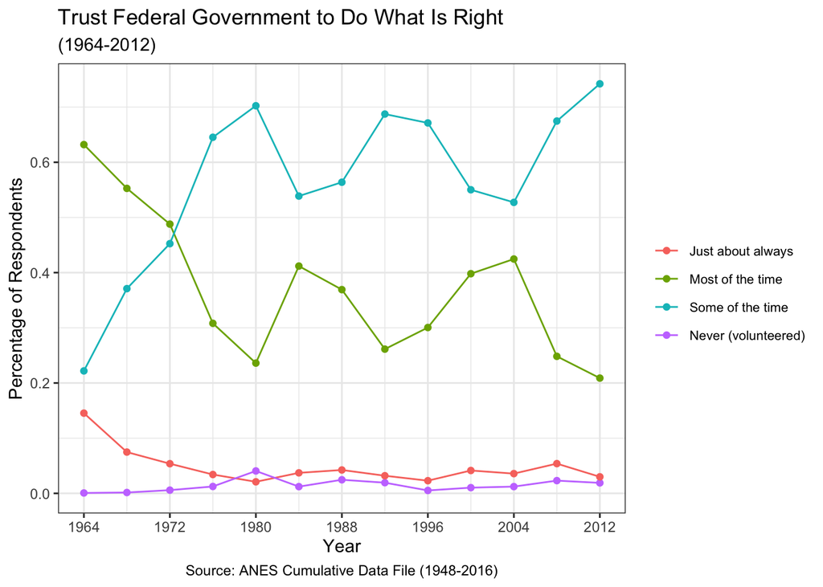

#### Poltical Efficacy

There are many questions that come together to assess political efficacy, but whether or not respondents agree that public officials care what they think is a fundamental component of efficacy. The ANES asks respondents whether they agree with the following statement:

*I don’t think that public officials care much what people like me think. (1952-2016)*

```
##              careWhatIThink     n percent
##                       Agree 23330   50.5%
##                    Disagree 19439   42.1%
##  Neither agree nor disagree  3438    7.4%
```

Since this question uses the phrase “people like me” I thought it would be worthwhile to visualize how responses breakdown across typical demographic categories. There was not much difference in responses by race; there were however significant difference when plotting by level of education. We know that turnout is positively correlated with education. This plot illustrates that political efficacy is likewise associated with education. The covariance of education and efficacy tells us that political efficacy— represented here by the respondent’s belief that elected officials care what they think—must also be positively correlated with turnout. This plot only includes data from presidential election years since 2000. I chose to only plot recent elections since the educational attainment of the electorate has changed so dramatically since the ANES began in fielding this question in 1952.

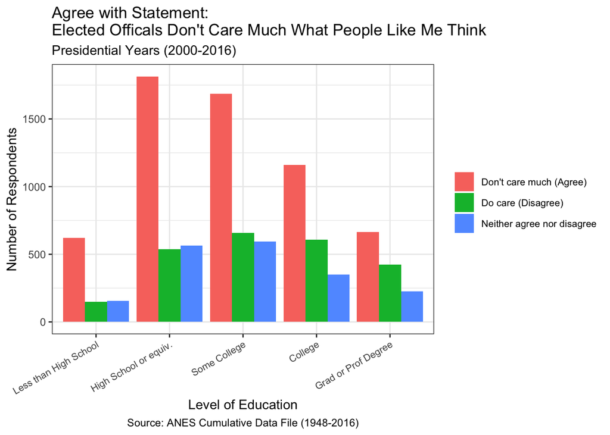

#### Political Complexity

ANES also asks respondents whether they agree or disagree that politics is too complicated, another component of political efficacy.

*Sometimes politics and government seem so complicated that a person like me can’t really understand what’s going on. (1952-2012)*

```
##                 complicated     n percent
##                       Agree 25911   67.6%
##                    Disagree 10774   28.1%
##  Neither agree nor disagree  1621    4.2%
```

I can use a chi squared test to evaluate the relationship between two categorical variables. A chi squared test determines whether there is a statistically significant difference between the expected frequencies under the null and the observed frequencies. Here the null hypothesis is that people who think that government is too complicated to understand and those who disagree with that statement will turnout to vote at equal rates. The alternative hypothesis is that the groups vote at different rates. I am able to reject the null and adopt the alternative hypothesis at the a=0.05 significance level if the p-value is less than 0.05. Executing the chi squared test and examining the residuals shows that `complicated` is highly significant. People who think politics is complicated are much more likely to not vote, and people who disagree are significantly more likely to cast a vote.

```
##                 complicated did not vote voted
##                       Agree        29.7% 70.3%
##                    Disagree        15.6% 84.4%
##  Neither agree nor disagree        29.3% 70.7%
```

```
##
##  Pearson's Chi-squared test
##
## data:  compTable
## X-squared = 549.62, df = 2, p-value < 2.2e-16
```

```
##                 complicated did not vote     voted
##                       Agree    10.685642 -6.260289
##                    Disagree   -16.993542  9.955835
##  Neither agree nor disagree     2.492377 -1.460184
```

### Visualization

It was hard for me to decide what kind of visualization to use. With so many binary and categorical variables but very few numeric responses, I was limited in which types of visualizations I could try. Ideally, I would have liked to combine responses from multiple ANES “system support” questions into a political efficacy index which I could visualize or use in a regression. But it didn’t make sense for me to arbitrarily add a bunch of variables together and then use a methodologically unsound, untested index. That said, I hope to learn how indices of racial resentment, political knowledge, political efficacy, etc. are constructed and evaluated so that I am able to do something more complex in the future.

### Reflection

The most time consuming visualization that I worked on for this course was the trend of trust over time. First I had calculate proportion of respondents for each level of trust and save that table as new data frame. When I did it initially, I used `prop.table()`, but `prop.table()` is difficult to work with because it erases the metadata from the original data frame. `tabyl()` from the `janitor` package resolves this problem and produces a data frame with the same dimensions, labels, and variable types as the `tabyl()` itself. When I used `prop.table()` it took me hours to tidy and the new data frame and get the data in the format I needed for `ggplot`. That struggle and subsequent realization that *it could have been so much easier* was actually reassuring for me. It helped me recognize that there is a learning curve with R—perhaps a steep learning curve—but that once I’m familiar with the program and really know what its capable of, things will go a lot more smoothly.

The other thing that I struggled with in R throughout this course was importing my data into R and getting it to load correctly. Prior to this course, I assumed the tidying process was only about manipulating data into a workable rectangular shape and labeling variables which takes place after the data are already in the R environment. But I learned that not only can importing data be just as difficult, but that it is the essential first step in the tidy data process. I got tripped up twice, first importing the `anes_2016` data and then the ANES cumulative file, because R imported many variables imported as the wrong variable type. A vector’s `class()` restricts what kinds of operations can be preformed on it; therefore having data that is the wrong class can be a serious problem. Sometimes you can just use functions like `as.numeric()`, `factor()`, or `unclass()` to change the class to the type you want, but I needed other solutions to fix my import problems. Both datasets were composed almost entirely of double vectors but the 2016 file imported as mostly character vectors and the cumulative file as mostly logical vectors. Wickham and Grolemund’s *R for Data Science* is an invaluable resource. Their chapter on data import explained that R has parsing problems if the first 1000 rows have missing data which was my problem with the ANES cumulative file.[^6] In both cases, I only realized something was wrong because the tidying and renaming that I was attempting to do, wasn’t working the way it should have been. In part, I didn’t notice because I couldn’t understand what the big blocks of red warning text were trying to tell me. I looked at them, but the text was meaningless to me at the time. Ignoring these warnings just caused problems later on. Consequently, another major improvement I’ve made as I’ve adjusted to R in just the past few weeks, is that I now know the importance of reading and understanding those warning and error messages. At this point I’m better able to intuit what many of them mean on my own, but when I don’t know, I know enough to google it.

### Conclusion

One supplementary data source I could use to extend this research is the “Voting and Registration Supplement” included in the Current Population Survey (CPS). The CPS is a monthly survey conducted by jointly by the Census Bureau (CB) and Bureau of Labor Statistics (BLS). The voter supplement is added to the November survey in years with a federal election. It is used to calculate official turnout statistics which is the reason I found it while writing this introduction. It asks respondents if they are registered to vote, their method of registering, whether they voted, their method of voting, if they voted on or before election day, and importantly, if applicable, *why* they did not register or cast a ballot. The most common responses include too busy, not interested, disability/illness, inconvenient, and registration problems.[^7] There aren’t any political questions on the CPS so I would not be able to analyze ideology. But the CPS includes detailed demographic data; therefore I could do an in-depth comparison of the race, education, and income of voters and non-voters.

[^1]: File, T. (2017, May 10). *Voting in America: a look at the 2016 presidential election.* United States Census Bureau. https://www.census.gov/newsroom/blogs/random-samplings/2017/05/voting_in_america.html
[^2]: Misra, J. (2019, April 23). *Voter turnout rates among all voting age and major racial and ethnic groups were higher than in 2014.* United States Census Bureau. https://www.census.gov/library/stories/2019/04/behind-2018-united-states-midterm-election-turnout.html
[^3]: Powell, G. B. (1986). American voter turnout in comparative perspective. *The American Political Science Review*, 80(1), 17-43. doi:10.2307/1957082
[^4]: The American National Election Studies (2019) *The ANES time series cumulative data file* (Version SDA 4). The University of Michigan and Stanford University with grants from the National Science Foundation [Data file and code book]. https://sda.berkeley.edu/sdaweb/analysis/?dataset=nes2016c
[^5]: The American National Election Studies (2017). *The ANES 2016 time series study* (Version SDA 4) The University of Michigan and Stanford University with grants from the National Science Foundation [Data file and code book]. https://sda.berkeley.edu/sdaweb/analysis/?dataset=nes2016
[^6]: Wickham, H. & Grolemund, G. (2016). *R for Data Science.* [eBook edition]. O’Reilly Media, Inc. https://r4ds.had.co.nz/
[^7]: Flood, S., King, M., Rodgers, R., Ruggles, S., & Warren, J. R. (2020). *Integrated Public Use Microdata Series, Current Population Survey* (Version 7.0) University of Minnesota. [Data file and code book]. https://doi.org/10.18128/D030.V7.0